# Green or greenwashed? Examining consumers' ability to identify greenwashing - ScienceDirect

## [Journal of Environmental Psychology](https://www.sciencedirect.com/journal/journal-of-environmental-psychology)

[Volume 95](https://www.sciencedirect.com/journal/journal-of-environmental-psychology/vol/95/suppl/C), May 2024, 102281

# Green or greenwashed? Examining consumers' ability to identify greenwashing

,

https://doi.org/10.1016/j.jenvp.2024.102281[Get rights and content](https://s100.copyright.com/AppDispatchServlet?publisherName=ELS&contentID=S0272494424000549&orderBeanReset=true)

Under a Creative Commons [license](http://creativecommons.org/licenses/by/4.0/)

Open access

## Highlights

- •

  Categorization theory is used to test consumers' ability to identify greenwashing.
- •

  Consumers can distinguish honest green from greenwashed products if they are primed.
- •

  What is on consumers' minds affects their ability to identify greenwashing.
- •

  Activating a greenwashed product category can help consumers to detect greenwashing.

## Abstract

Nowadays, companies and consumers face the challenge of navigating around the pitfalls of greenwashing in markets presenting uncountable new and existing green products. This research examines consumer perceptions of such products and the extent to which consumers are able to identify greenwashing. Drawing on categorization theory, consumers may classify a new product based on different green cues as honest green, greenwashed, or non-green. We test this ability across three different products in two experimental studies (*N* = 700) conducted in Germany and find that consumers fall for greenwashing when they are asked solely for their purchase intentions. Activating a greenwashed product category by asking participants for their perceived greenwashing helped them to spot the differences between the green products. This research contributes to the literature by directly examining consumers' ability to distinguish between greenwashed and honest green products and by providing empirical evidence that consumers can do so when they are primed. That is, the activation of a greenwashed product category can support consumers in identifying greenwashing. Practically speaking, this research may point public policy toward category activation as a simple measure to help consumers unmask greenwashing in purchase contexts.

## Keywords

Greenwashing

Green advertising

Sustainability communication

Consumer perception

Green product cue

Categorization

## 1. Introduction

There has been a marked increase in the general public’s concern for [environmental issues](https://www.sciencedirect.com/topics/social-sciences/environmental-issue), evident in global movements such as Fridays for Future (Wallis & Loy, 2021) and public policy efforts as part of the European Green Deal (European Commission, 2023). A corresponding interest in more sustainable consumption has led companies to increasingly market products as environmentally friendly or green (Kwon et al., 2023; Leonidou & Skarmeas, 2017; Segev et al., 2016). At the same time, the occurrence of greenwashing, which describes “communication that misleads people into adopting overly positive beliefs about an organization’s environmental performance, practices or products” has grown rapidly (Lyon & Montgomery, 2015, p. 226). In this context, genuinely sustainable companies that do not engage in greenwashing practices face the challenge of communicating sustainable product improvements without raising consumer suspicion of greenwashing (Newell et al., 1998; Steenis et al., 2022). Simultaneously, responsible consumers who intend to protect the environment face the challenge of distinguishing between greenwashed and honest green products when making purchases (Newell et al., 1998; Schmuck et al., 2018). Notably, if consumers are not able to identify greenwashing, companies will have an incentive to greenwash which can undermine genuine attempts to improve corporate and product sustainability (European Commission, 2023; Fernandes et al., 2020).

Related academic research has surged with the occurrence of greenwashing and can be divided into two literature streams: One looks at corporate greenwashing with a focus on drivers, types, and consequences of greenwashing on a company level, primarily anchored in organization and management studies (e.g., Leonidou & Skarmeas, 2017; for a review see Lyon & Montgomery, 2015). The other looks at (misleading) green advertising with a focus on the product level and consumer responses such as ad and brand attitudes as well as purchase intentions, emerging from marketing and advertising research (e.g., Schmuck et al., 2018; Schuhwerk & Lefkoff-Hagius, 1995; Steenis et al., 2022). Yet, in this second stream, research assessing how green(washed) cues of respective products are perceived by consumers has been scarce (Kwon et al., 2023; Matthes, 2019; Newell et al., 1998; Pancer et al., 2017; Schmuck et al., 2018; Szabo & Webster, 2021). More specifically, the question arises to what extent consumers are able to distinguish between greenwashed and honest green companies and their respective products (Matthes, 2019; Pancer et al., 2017). Notably, many theoretical and practical implications emerging from research on greenwashing or green advertising may be futile if consumers actually cannot identify greenwashing (Newell et al., 1998).

Against this practical and theoretical background we ask: Are consumers able to identify greenwashing, namely, can they distinguish between greenwashed, honest green, and non-green products? To answer this research question, we draw on categorization theory according to which consumers navigate through the myriad of new and existing green products with the help of categorical representations of such products to classify and understand respective product information (Loken et al., 2008). Thereby, consumers use relevant environmental cues representing the green product category and evaluate to which degree the new product is similar to it. For example, the category of green cleaning detergents may be represented through plant-based and biodegradable ingredients, an eco-label, and green package color (Fernandes et al., 2020; Pancer et al., 2017; Schuhwerk & Lefkoff-Hagius, 1995). By combining different green, greenwashed, and non-green product cues, prototypical categories of an honest green, greenwashed, and non-green product are operationalized as stimuli for three different products (Simula & Lehtimäki, 2009; Szabo & Webster, 2021). In a first step, these stimuli were shown to German convenience samples in three within-subject experiments to evaluate the extent to which participants could recognize the green(washed) product based on its cues. In a second step, a mixed experimental design was applied to support the prior findings with a consumer sample that approximates the German population in terms of age and gender and to gain further insights into the underlying [cognitive process](https://www.sciencedirect.com/topics/psychology/cognitive-process).

This research offers important contributions on theoretical and practical accounts. On a theoretical level, we directly examine consumers' ability to distinguish honest green from greenwashed products and provide empirical evidence that consumers can do so when they are primed. We further show that what is on consumers' minds (i.e., two or three category representations) affects their ability to identify greenwashing. For practitioners, our insights point to the potential of activating a greenwashed category to help consumers detect greenwashing in purchase contexts.

## 2. Theoretical background and hypotheses

### 2.1. Categorization theory in the context of green(washed) products

According to categorization theory (for a review, see Loken et al., 2008), consumers use categories, that is, mental collections of objects that appear to be related in some way (Rosch, 1978), from which they make inferences to evaluate products. Hereby, a distinction is made between *categorical representations*, which describe the information stored in consumers' memories that identifies a consumer category (such as a set of products) and *category inference*, which denotes the process in which consumers use these categories to make judgments about new category members. Essential to this categorization process is the degree to which the representation of the product category matches the new product, also known as “similarity as heuristic” (Loken et al., 2008, p. 145). If similarity is low, it is unlikely that inferences will be drawn from the product category to the new member compared to when similarity is high.

Applied to the realm of green products, category inference influences how consumers respond to products with environmental cues (Gershoff & Frels, 2015; Lee et al., 2020; Pancer et al., 2017). Thereby, consumers can use four distinct categorical representations depending on how an organization’s green advertising level (i.e., the extent to which environmentally friendly product features are communicated as a persuasive selling point; Atkinson & Rosenthal, 2014) matches the actual sustainability of their products (Simula & Lehtimäki, 2009; Szabo & Webster, 2021): *Honest green* products require that both the green advertising level and the product sustainability are high, while *honest non-green* products result when both are low. If only the green advertising level is high, but actual product sustainability is low, a *greenwashed* product is described. The fourth and final combination occurs when the green advertising level is low, but product sustainability is high. Such corporate behavior has been studied as *green muting, green blushing,* or *green hushing* in the academic literature (e.g., Acuti et al., 2022; Falchi et al., 2022; Szabo & Webster, 2021) and will not be further investigated in this research for two reasons: First, this category does not help scrutinize consumers' ability to identify greenwashing because the actual sustainability of the products in this category is not advertised (i.e., observable). Therefore, consumers would not be able to identify these products as green and differentiate them from non-green products. Second, it seems rather unlikely that most of today’s organizations would not want to share the sustainability benefits of an actually sustainable product, as sustainability seems to have become an overall desirable product feature to communicate (Kwon et al., 2023; Leonidou & Skarmeas, 2017; Segev et al., 2016; Szabo & Webster, 2021).

Based on this conceptualization, the present research examines the extent to which consumers are able to distinguish between the three outlined product categories. To this end, this research follows a prototype view of category representation, in which categories are represented by general, abstracted composites or prototypes (Loken et al., 2008). Next, we will identify such prototypes for green(washed) products, which are based on the most likely features from a product that is member of the respective category (Rosch, 1978). Therefore, the following section provides a review of different green(washing) cues upon which each introduced product category may be represented in consumers' minds and used for category inference.

### 2.2. Category representation based on verbal and visual green(washing) cues

While some studies have focused on verbal (e.g., Schuhwerk & Lefkoff-Hagius, 1995) or visual cues only (e.g., Hartmann & Apaolaza-Ibáñez, 2010), the majority of research on green advertising examined both types of green product cues (Fernandes et al., 2020; Granato et al., 2022; Magnier & Schoormans, 2015; Schmuck et al., 2018; Steenis et al., 2022). This matches how products are marketed in practice (Kwon et al., 2023; Segev et al., 2016).

Starting with claims as verbal cues, a green product claim consists of one or more sentences that inform consumers about the environmental contribution of the advertised product (Segev et al., 2016). When such verbal cues are misleading, this is termed “claim greenwashing” (Parguel et al., 2015, p. 108). Drawing on specific misleading claims reflected in the seven “Sins of Greenwashing” (TerraChoice, 2010, p. 10), extant research has examined hidden trade-offs (Steenis et al., 2022), vague (Fernandes et al., 2020) as well as false claims (Newell et al., 1998; Schmuck et al., 2018). Because vague claims have been very prevalent in [marketing green](https://www.sciencedirect.com/topics/social-sciences/green-marketing) products and because false claims posit another major type of misleading cue (Carlson et al., 1993; European Commission, 2023; Kangun et al., 1991; Segev et al., 2016), this research will use both claim types as verbal greenwashing cues. Specifically, *vague* claims are poorly defined or overly broad and can therefore be misunderstood by consumers, whereas *false* claims are simply false against objective evidence, representing outright lies (Kangun et al., 1991; Schmuck et al., 2018; TerraChoice, 2010). Interestingly, cross-cultural research found that the more prevalent vague claims were unrelated to perceived greenwashing (i.e., are particularly misleading), while the less prevalent false claims significantly increased greenwashing perceptions (Schmuck et al., 2018), further warranting the use of both claim types in this research. Adding *irrelevant* claims, which present requirements that are imposed by law as distinctive product features (European Commission, 2023; TerraChoice, 2010), will complete our selection of verbal greenwashing cues.

Visual cues depict an ad’s physical layout and include logos, nature imagery, colors, and backgrounds (Segev et al., 2016). Notably, when visuals are applied without any explicit reference to the actual environmental benefits of the advertised products, this is termed “executional greenwashing” (Parguel et al., 2015, p. 108; Schmuck et al., 2018). The simplest visual cue is the use of *green color*, which consumers tend to associate with environmental friendliness, regardless of the product’s actual sustainability (Pancer et al., 2017; Seo & Scammon, 2017). In addition, research has shown that *nature imagery* (e.g., forests, wild creeks, or butterflies) positively influences brand attitudes (Hartmann & Apaolaza-Ibáñez, 2010; Hartmann et al., 2016) and specifically, enhances perceptions of a brand’s ecological image even when objective information states inferior environmental performance (Parguel et al., 2015). Finally, eco-labels have been frequently used to market green products (European Commission, 2023; Segev et al., 2016). Notably, a distinction is made between third-party certified labels (e.g., by governmental institutions or non-governmental organizations) and labels without such external validation (e.g., self-declared company labels or mere graphic logos; Atkinson & Rosenthal, 2014; Pancer et al., 2017). Importantly, such *false* or *fake labels* can give consumers a wrong impression of third-party endorsement (Lyon & Montgomery, 2015; Segev et al., 2016; TerraChoice, 2010). When official or false eco-labels, nature imagery, and green color are combined, they typically yield an overall green look-and-feel (Segev et al., 2016), which will be applied to visually cue both the greenwashed and honest green product category in this research.

### 2.3. Examining consumers' ability to identify greenwashing

To test the extent to which consumers are able to identify greenwashing, the formerly introduced product categories of an honest green, greenwashed, and non-green product need to be operationalized using prototypical verbal and visual green(washed) cues representing these categories. Notably, extant research showed that the isolated use of an environmental cue introduces category ambiguity, while providing two cues (such as an eco-label and green color) helps consumers to clearly categorize a product as environmental (Lee et al., 2020; Pancer et al., 2017). Hereby, it is relevant that different environmental cues (e.g., verbal and visual) are congruent in communicating a product’s greenness (Magnier & Schoormans, 2015). In this context, prior studies have shown that verbal and visual cues affect product perceptions and evaluations in different ways: Schmuck et al. (2018) found that verbal cues are processed through a more rational mechanism, while visual cues are processed through a more affective mechanism. Likewise, Parguel et al. (2015) suggested that verbal cues follow a more central route to persuasion, while visual cues follow a more peripheral route. Therefore, we combine the outlined multiple verbal and visual green(washing) cues to operationalize the greenwashed, honest green, and non-green product as evident and unambiguous as possible, thereby accounting for these different processing mechanisms (Matthes, 2019).

To determine to what extent consumers recognize the honest green and greenwashed products as such, this research focuses on consumers' perceptions of greenness and greenwashing. Following extant research, perceived greenness measures the extent to which consumers evaluate a product as environmentally friendly (Gershoff & Frels, 2015) while perceived greenwashing describes the extent to which consumers believe a product to be misleading with regard to its environmental benefits (Chen & Chang, 2013; Schmuck et al., 2018). If consumers can identify greenwashing, a greenwashed product cued by a vague, false, and irrelevant claim as well as by green color, nature imagery, and fake eco-labels will elicit higher greenwashing perceptions and lower perceptions of greenness. At the same time, an honest green product cued by a specific, true, and relevant claim as well as by green color, nature imagery, and official eco-labels will lead to lower greenwashing perceptions and higher perceptions of greenness. Therefore, consumers' ability to identify greenwashing can be derived from the differences in these product perceptions (Schmuck et al., 2018; Steenis et al., 2022). Going beyond product perceptions, various consumer responses to green(washed) products have been studied in the green advertising literature. In particular, extant research has shown that perceived greenwashing positively affects consumer confusion and perceived risk (Chen & Chang, 2013), and negatively affects green trust (Chen & Chang, 2013), advertiser credibility (Newell et al., 1998), attitude toward the ad and brand (Fernandes et al., 2020; Newell et al., 1998), as well as purchase intentions (Newell et al., 1998; Schmuck et al., 2018; Steenis et al., 2022; Szabo & Webster, 2021). This research uses purchase intention to measure product preference. Therefore, if consumers are able to detect greenwashing this will likely reflect in their purchase intentions so that a product categorized as greenwashed will be least preferred. This leads to the following set of hypotheses:

**H1**

Consumers' purchase intention is higher for an honest green and a non-green product than for a greenwashed product.

**H2**

Consumers' perceived greenness is higher for an honest green product than for a greenwashed and a non-green product.

**H3**

Consumers' perceived greenwashing is higher for a greenwashed product than for an honest green and a non-green product.

This general phenomenon to what extent consumers are able to distinguish between honest green and greenwashed products will be tested in Studies 1a-c.

### 2.4. The role of category activation in consumers' ability to identify greenwashing

Next to the question to what extent consumers can identify greenwashing, it is at least as important to examine the [cognitive process](https://www.sciencedirect.com/topics/psychology/cognitive-process) that affects this ability (Lyon & Montgomery, 2015). In this research, consumers are tested regarding their ability to distinguish between two green-looking products, of which one is honestly green and the other is greenwashed. In terms of categorization theory, consumers need to access a categorical representation of greenwashed products to be able to categorize the greenwashed product as such. Therefore, the question arises under what condition this greenwashed product category is activated. While prior research suggests that the mere exposure to green(washed) cues on a product can be sufficient to activate an environmental schema (Pancer et al., 2017), the objective with which consumers evaluate a product can also influence category activation (Macrae et al., 1995). In particular, consumers do not usually evaluate each and every product regarding perceptions of greenness or greenwashing, but regarding their purchase intentions. In doing so, it is conceivable that consumers do not necessarily have a greenwashed category on their minds. Therefore, when evaluating their purchase intentions for an honest green, greenwashed, and non-green product, consumers may only access a green and a non-green category (arising from their distinct visual appearance), rendering consumers less capable of recognizing the greenwashed product.

To examine the role of category activation depending on the objective of a [product evaluation](https://www.sciencedirect.com/topics/agricultural-and-biological-sciences/product-evaluation), the following rationales serve as the basis for additional hypotheses to be tested: If consumers indeed only access a green and a non-green category when evaluating their purchase intentions, then they will less likely think of greenwashing and, thus, cannot have a (third) greenwashed product category in mind. Second, when consumers think in only these two basic categories (Rosch, 1978), it is conceivable that they will perceive both green-looking products to be similar and in contrast to the non-green product. In this research, this is more likely if they attend more to the shared visual cues (i.e., green color and nature imagery) than to the distinct verbal cues. Third, thinking in green and non-green categories will lead consumers to need longer to categorize the greenwashed product because they need to access a third category which they have not thought of before (Loken et al., 2008). For the same reason, consumers are expected to more often wrongly categorize the greenwashed product. From this, we hypothesize the following:

**H4**

When consumers evaluate purchase intentions (vs. perceived greenness and greenwashing), they will report fewer greenwashing thoughts.

**H5**

When consumers evaluate purchase intentions (vs. perceived greenness and greenwashing), they will mention (a) shared visual cues more often and (b) distinct verbal cues less often.

**H6**

When consumers evaluate purchase intentions (vs. perceived greenness and greenwashing), they will (a) need more time to categorize the greenwashed product and (b) more often wrongly categorize it.

Study 2 will examine whether consumers' ability to identify greenwashing depends on the number of categories that come to mind depending on what they are asked to evaluate.

## 3. Studies 1a-c

To investigate to what extent consumers are able to identify greenwashing, we conducted three online experiments across three different products in Germany. Each experiment contained three conditions: an honest green, a greenwashed, and a non-green (control) product stimulus. Because the purpose of the experiments was to examine the extent to which one and the same consumer is able to distinguish between these product stimuli, a within-subject design was applied in which each participant evaluated all three of them. Compared to a between-subject design, this also enabled a more realistic decision context as consumers are usually confronted with competing products that may be greenwashed, honest green, or non-green (Vargas et al., 2017). Moreover, this design provided a rather conservative approach to test consumers' ability to identify greenwashing as each participant could compare the three different product stimuli. The experimental design was applied to three different product types frequently studied in consumer research: two low-involvement products of which one is associated with strength-related (toilet cleaner) and one with gentleness-related attributes (hand cream) as well as one high-involvement product (smartphones) (Atkinson & Rosenthal, 2014; Skard et al., 2021). A pilot study (*N* = 96) ensured that the selected products are adequate to represent the respective product type (details are presented in the supplemental online material).

### 3.1. Methods

#### 3.1.1. Participants

Three German convenience samples were recruited between September 2021 and June 2023. A power analysis conducted in G*Power using an alpha of 0.05, a power of 0.95, and a conservative estimation of a small effect size (*f* = 0.15) suggested a sample size of 117. To account for exclusions due to non-existing product experience, we aimed for a sample size of 150 participants. For each experiment, participation was incentivized with the option to enter a sweepstake for four 15 Euro shopping vouchers upon survey completion. Participants were told that the studies were about the perception of an everyday product to avoid any early associations with greenwashing and related demand effects (Geuens & Pelsmacker, 2017). 153 useable responses were collected for toilet cleaners (20–29 years: 69%; female: 67%, non-binary: 0%; full-time employees: 35%) in Study 1a, 157 responses for hand cream (*M*<sub>age</sub> = 30 years; female: 73%, non-binary: 2%; full-time employees: 37%) in Study 1b, and 162 responses for smartphones (*M*<sub>age</sub> = 29 years; female: 59%, non-binary: 0%; full-time employees: 32%) in Study 1c. All participants reported that they have previously used or bought the respective product.

#### 3.1.2. Product stimuli

For each experiment, we used three pictures of fictitious toilet cleaners (Study 1a), hand creams (Study 1b), or smartphones (Study 1c), which were created by professional media and graphic designers based on existing products (see Table A1, Table A2, Table A3). To reduce bias, the order in which the three stimuli were shown was counterbalanced and randomly assigned to each participant. Furthermore, participants were informed that the products had the same price to rule out any unforeseen effects thereof. The stimuli differed in the following verbal and visual cues:

The non-green products carried a neutral brand name (e.g., ‘clean right’) whereas the greenwashed and honest green products carried a brand name indicating sustainability (e.g., ‘clean green’). Fictitious brand names were chosen to avoid consumers inferring categories solely based on brand names and, thus, prevent bias due to personal experiences or expectations of known brands (Geuens & Pelsmacker, 2017; Lee et al., 2020; Loken et al., 2008). Furthermore, each product picture showed three different claims which referred to the actual product and not its packaging (despite being placed *on the* packaging)<sup>1</sup>: In line with our conceptualization, the greenwashed products contained a vague, a false, and an irrelevant claim. In contrast, the honest green products stated a specific, a true, and a relevant claim. The three claims on the non-green products referred to its functionality rather than environmental benefits (see Table A1, Table A2, Table A3).

Turning to the visual cues, the honest green and greenwashed products shared the same green color and nature imagery to avoid any design-related preferences consumers could have between these products. However, honest green products carried two official eco-labels (e.g., European eco-label and V-Label), while greenwashed products carried two fake labels to make them look like officially certified green products (see Table A1, Table A2, Table A3). The non-green products displayed neither green color and nature imagery nor labels.

#### 3.1.3. Measures

All items of the following measurement scales and their reliabilities can be found in Table A4. To minimize demand effects, the three main outcome variables were asked in the following order (Geuens & Pelsmacker, 2017): After viewing each product stimulus, we first queried purchase intention using the scale by Bian and Forsythe (2012) based on Dodds et al. (1991). Next, each stimulus was presented again in the same order as before. This time, we assessed perceived greenness with four items following Gershoff and Frels (2015). When each product was shown for the last time, we measured perceived greenwashing using five items from Chen and Chang (2013) and a sixth item by Schmuck et al. (2018) to also explicitly cover false claims. Participants responded to all items on 7-point rating scales and the order in which the items for each scale were shown was randomized. To screen out participants without product experience, they were asked if they had ever used or bought the respective product. Because the studies were carried out in Germany, all items were translated into German.

#### 3.1.4. Manipulation check

After the three main outcome variables were queried, each experiment included a manipulation check for the greenwashed product cues. Following extant research (Schmuck et al., 2018), we first asked “Which symbol(s) stand(s) for a certified label for environmentally friendly products?”. The answer options contained the four labels which had already been shown on the respective greenwashed and honest green product. This way, we could test whether the official and fake labels indeed were recognized as such. To control whether the false and vague claims on the greenwashed product were perceived as such, participants were asked to agree or disagree to the statements “This claim is vague” and “This claim is factually wrong” for each of the two presented claims. The irrelevant claims were not covered in the manipulation check because they provided information required by law, and thus, were based on objective facts.

### 3.2. Results

#### 3.2.1. Manipulation check

Across the three experiments, the official labels were correctly identified by the majority of participants (53%–83%), while only few falsely selected the fake labels (3%–25%). Therefore, most participants recognized official labels as such and the fake labels can be considered adequate to cue the greenwashed products. Turning to the claims, participants rated the false claims as “false” to a significantly higher degree than as “vague” (with one exception in Study 1b). Likewise, the vague claims were rated as “vague” to a significantly higher degree than as “false”. Overall, the manipulation check for labels and claims can be considered successful (details are available in the supplemental online material). Please note that no participants were excluded due to a failed component of the manipulation check because of the risk of introducing confounds (Meyvis & van Osselaer, 2018).

#### 3.2.2. Effects on purchase intention

Three repeated measures [ANOVAs](https://www.sciencedirect.com/topics/psychology/analysis-of-variance) with a Huynh-Feldt correction and post hoc analyses with a Bonferroni adjustment were applied to compare the mean purchase intentions for each product (see Fig. 1 and supplemental online material).

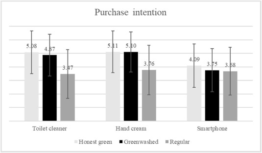

Fig. 1. Purchase intention for the three stimuli per product (Studies 1a-c). Error bars represent the standard deviation of means.

##### 3.2.2.1. Study 1a: toilet cleaner

Mean purchase intention differed significantly between the three toilet cleaners (*F*(1.609, 244.626) = 84.243, *p <* 0.001, partial η<sup>2</sup> = 0.357). Post hoc analysis revealed that purchase intention differed only marginally significantly between the honest green (*M* = 5.08) and the greenwashed product (*M* = 4.87, *p* = 0.078). Notably, purchase intention for the non-green product (*M* = 3.47) was significantly *lower* than for the greenwashed (*M* = 4.87, *p* < 0.001). Thus, H1 was not supported for toilet cleaners.

##### 3.2.2.2. Study 1b: hand cream

Mean purchase intention varied significantly between the three hand creams (*F* (1.717, 267.810) = 56.295, *p <* 0.001, partial η<sup>2</sup> = 0.265). Post hoc analysis showed that purchase intention did not significantly differ between the honest green (*M* = 5.11) and the greenwashed product (*M* = 5.10, *p* = 1.000). Again, purchase intention for the non-green product (*M* = 3.76) was significantly *lower* than for the greenwashed (*M* = 5.10, *p* < 0.001). Therefore, H1 was not supported for hand creams.

##### 3.2.2.3. Study 1c: smartphone

Mean purchase intention differed significantly between the three smartphones (*F*(1.892, 304.535) = 5.752, *p =* 0.004, partial η<sup>2</sup> = 0.034). Post hoc analysis revealed that purchase intention was significantly higher for the honest green (*M* = 4.09) than for the greenwashed product (*M* = 3.75, *p* = 0.008). However, there was no significant difference between purchase intention for the non-green (*M* = 3.68) and the greenwashed product (*M* = 3.75, *p* = 1.000). Thus, H1 was only partially supported for smartphones.

#### 3.2.3. Effects on perceived greenness

Three repeated measures [ANOVAs](https://www.sciencedirect.com/topics/food-science/analysis-of-variance) with a Huynh-Feldt correction and post hoc analyses with a Bonferroni adjustment were applied to compare the mean perceived greenness of each product (see Fig. 2 and supplemental online material).

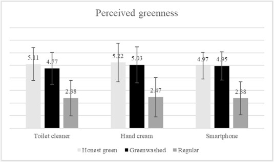

Fig. 2. Perceived greenness of the three stimuli (Studies 1a-c). Error bars represent the standard deviation of means.

##### 3.2.3.1. Study 1a: toilet cleaner

Mean perceived greenness differed significantly between the three toilet cleaners (*F*(1.780, 270.554) = 265.199, *p* < 0.001, partial η<sup>2</sup> = 0.636). Post hoc analysis revealed that perceived greenness was significantly higher for the honest green product (*M* = 5.11) than for the greenwashed (*M* = 4.77, *p* = 0.005) and non-green product (*M* = 2.38, *p* < 0.001), supporting H2.

##### 3.2.3.2. Study 1b: hand cream

Mean perceived greenness varied significantly between the three hand creams (*F*(1.850, 288.559) = 251.032, *p* < 0.001, partial η<sup>2</sup> = 0.617). Post hoc analysis revealed that perceived greenness was significantly higher for the honest green (*M* = 5.22) than for the non-green product (*M* = 2.47, *p <* 0.001). However, there was no significant difference between perceived greenness for the honest green (*M* = 5.22) and the greenwashed product (*M* = 5.03, *p* = 0.284). Thus, H2 was only partially supported for hand creams.

##### 3.2.3.3. Study 1c: smartphone

Mean perceived greenness differed significantly between the three smartphones (*F*(1.704, 274.376) = 234.124, *p* < 0.001, partial η<sup>2</sup> = 0.593). Post hoc analysis revealed that perceived greenness was significantly higher for the honest green (*M* = 4.97) than for the non-green product (*M* = 2.38, *p <* 0.001). Again, there was no significant difference between perceived greenness for the honest green (*M* = 4.97) and the greenwashed product (*M* = 4.95, *p* = 1.000). Thus, H2 was only partially supported for smartphones.

#### 3.2.4. Effects on perceived greenwashing

Two repeated measures ANOVAs which needed no correction for sphericity (toilet cleaner, hand cream) and one with a Huynh-Feldt correction (smartphone) followed by post hoc analyses with a Bonferroni adjustment were applied to compare the mean perceived greenwashing of each product (see Fig. 3 and supplemental online material).

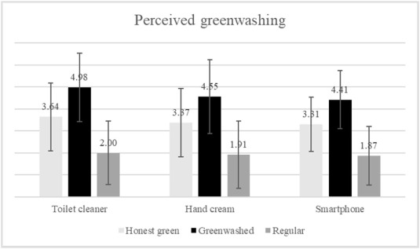

Fig. 3. Perceived greenwashing of the three stimuli (Studies 1a-c). Error bars represent the standard deviation of means.

##### 3.2.4.1. Study 1a: toilet cleaner

Mean perceived greenwashing differed significantly between the three toilet cleaners (*F*(2, 304) = 176.302, *p <* 0.001, partial η<sup>2</sup> = 0.537). Post hoc analysis revealed that perceived greenwashing was significantly higher for the greenwashed product (*M =* 4.98) than for the honest green (*M* = 3.64, *p <* 0.001) and non-green product (*M* = 2.00, *p* < 0.001), finding support for H3.

##### 3.2.4.2. Study 1b: hand cream

Mean perceived greenwashing differed significantly between the three hand creams (*F*(2, 312) = 137.862, *p <* 0.001, partial η<sup>2</sup> = 0.469). Again, post hoc analysis revealed that perceived greenwashing was significantly higher for the greenwashed product (*M =* 4.55) than for the honest green (*M* = 3.37, *p <* 0.001) and non-green product (*M* = 1.91, *p* < 0.001), supporting H3.

##### 3.2.4.3. Study 1c: smartphone

Mean perceived greenwashing differed significantly between the three smartphones (*F*(1.903, 306.428) = 145.572, *p <* 0.001, partial η<sup>2</sup> = 0.475). Once more, post hoc analysis revealed that perceived greenwashing was significantly higher for the greenwashed product (*M =* 4.41) than for the honest green (*M* = 3.31, *p <* 0.001) and non-green product (*M* = 1.87, *p* < 0.001, in support of H3.

### 3.3. Discussion of Studies 1a-c

Across three different products, Studies 1a-c empirically tested the extent to which consumers are able to distinguish between honest green, greenwashed, and non-green products (Simula & Lehtimäki, 2009; Szabo & Webster, 2021). Notably, when participants were first asked to report their *purchase intentions*, they seemed to fall for greenwashing: For toilet cleaners, purchase intentions were only marginally significantly different between the honest green and greenwashed products while for hand cream, no significant differences were found. Only the honest green smartphone was significantly preferred over the greenwashed one, as expected by H1. Moreover, the greenwashed product was actually preferred over the non-green one in the case of toilet cleaners and hand creams, while there was no significant difference in the case of smartphones. Therefore, we can summarize that H1 is not supported for the low-involvement products, and only partially supported for the high-involvement product. The finding that participants seem to be more susceptible to greenwashing in low- compared to high-involvement products is reasonable because consumers tend to invest less time in evaluating low-involvement products, and thus, pay less attention to their product cues (Atkinson & Rosenthal, 2014; Zaichkowsky, 1985). Overall, when consumers were asked for their purchase intentions, they were not always able to identify greenwashing. This finding is astonishing in light of a rather conservative manipulation of the product categories, which aimed to be very obvious by combining multiple verbal and visual green(washing) cues to make correct categorization as unambiguous as possible.

Turning to the effects on *perceived greenness*, we find that perceived greenness is higher for an honest green toilet cleaner than for a non-green and greenwashed one, in support of H2. However, for hand creams and smartphones there was no significant difference between the honest green and greenwashed products, providing only partial support for H2. This implies that (even) when consumers are asked to evaluate a product regarding its greenness, they may mistake the greenwashed for an honest green product. It appears that products in which consumers value environmental friendliness may be prone to this mistake: Hand creams offer gentleness-related product attributes, which consumers tend to associate with environmental friendliness, resulting in a sustainability asset effect (Luchs et al., 2010; Skard et al., 2021). For smartphones, research anchored in impression management concerns shows that environmental friendliness may also be desirable in high-involvement products (Griskevicius et al., 2010), leading to a similar asset effect.

Finally, across all three products *perceived greenwashing* was significantly higher for a greenwashed than for an honest green and non-green product, confirming H3. This shows that consumers can identify greenwashing at this point, regardless of the specific product. Such an enhanced differentiation process depending on what participants were asked to evaluate was also evident in an increasing absolute difference score of mean purchase intentions, perceived greenness, and perceived greenwashing of the honest green and greenwashed products (see Fig. 4). Notably, early research shows a similar pattern, where consumers could differentiate a deceptive from a neutral ad when asked for their perceived deception of each ad, but this differentiation was not evident when asked for their respective purchase intentions (Newell et al., 1998). Likewise, recent research also finds that consumers could detect greenwashed products when they were asked for their perceived deception, but not when they were asked for their perceived sustainability (Steenis et al., 2022).

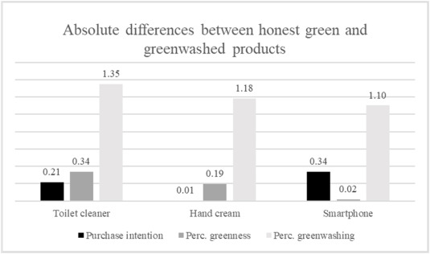

Fig. 4. Absolute differences between honest green and greenwashed products depending on questions asked (Studies 1a-c).

Overall, the results indicate that the ability to identify greenwashing may require category activation beyond the product type and the presented green(washed) product cues, as participants were able to distinguish between the honest green and greenwashed products when being asked for perceived greenwashing. This suggests that participants asked for their purchase intention may initially only access two basic category representations which first come to their minds: a green and a non-green product category. It appears that when participants' attention was directed more toward the green(washed) cues by asking them about their perceived greenness and, subsequently, perceived greenwashing, then they started to retrieve a third category, namely, that of greenwashed products. This idea, that consumers can be supported in detecting greenwashing by activating a greenwashed category through the objective with which a product is to be evaluated, was tested next.

## 4. Study 2

The aim of Study 2 was to replicate the prior results using a consumer sample that approximates the German population in terms of age and gender and to examine the underlying cognitive mechanism to explain when consumers detect greenwashing. Therefore, Study 2 was based on Study 1a with product as within-subject factor, but included the objective with which the products should be evaluated (i.e., type of questions asked) as between-subject factor. Thus, participants were randomly assigned to either respond to questions on purchase intention, perceived greenness, or perceived greenwashing after viewing each of three product stimuli. This mixed design had the advantage of eliminating potential confounding effects between the three closed question scales which now constitute three different between-conditions. Furthermore, it reduced the overall number of questions which enabled us to add a thought listing task (Cacioppo & Petty, 1981) and a categorization task to query participants' thoughts and explicit categorization of the product stimuli, respectively. The latter provides a direct measure of participants' ability to identify greenwashing in addition to the indirect measures based on their product perceptions and purchase intentions.

### 4.1. Methods

#### 4.1.1. Participants

A consumer sample was recruited from a panel provider in February 2023. By implementing sample quotas, efforts were made for the sample to approximate the German general population in terms of age and gender (details are presented in the supplemental online material). To have sufficient power (≥0.95) to detect a small effect size (*f* = 0.15) at an alpha of 0.05, a minimum sample size of 141 was calculated using G*Power. Some more participants were recruited to compensate for potentially insufficient response quality in the thought listing task, which was particularly relevant for H4 and H5. We first removed speeders (i.e., participants faster than 300 seconds)<sup>2</sup> and then controlled the response quality of the remaining participants. Those who failed to respond to all three thought listing tasks in a meaningful manner (i.e., single letters, punctuation marks, “none”, etc.) were also excluded. This resulted in 228 useable responses (*M*<sub>age</sub> = 47 years; female: 49.6%, non-binary: 0.4%; full-time employees: 49.6%). There was structural equality regarding age and gender between the three conditions (*n*<sub>PI</sub> = 71, *n*<sub>PG</sub> = 78, *n*<sub>GW</sub> = 79) and all participants reported that they have previously used or bought a toilet cleaner.

#### 4.1.2. Product stimuli and measures

Study 2 used the same product stimuli (toilet cleaners) and measures as Study 1a (see Tables A1 and A4). Following prior research (Granato et al., 2022; Schuhwerk & Lefkoff-Hagius, 1995), a thought listing task was added right after each closed question scale that related to one of three product stimuli: “Please write down any thoughts, reactions, or ideas that influenced your answers to the previous questions. Please describe them as completely and in as much detail as possible (as if you were thinking out loud).” Participants could respond using up to 15 text entry fields and take as much time as they needed. To identify the frequencies of participants' thoughts related to greenwashing, visual, and verbal cues, two graduate students blind to the experimental conditions and hypotheses served as independent observers (Cacioppo & Petty, 1981). Using a predefined code book, open responses were coded with regard to the occurrence of greenwashing thoughts, visual, and verbal cues, respectively (0 = no, 1 = yes, see Table B1). The first author checked the coding and resolved differences between coders.

After the last thought listing task, participants were asked to categorize each of the prior product stimuli as either non-green, green, or greenwashed product. The task was set-up so that each participant would view one product picture at a time (randomized in order) and could categorize it by clicking on one of three buttons stating the three abovementioned product categories. A hidden timing function of the survey measured how long it took participants to categorize each product. The survey proceeded with the same manipulation check questions as in Study 1a.

### 4.2. Results

#### 4.2.1. Replication of Study 1a

The manipulation checks for claims and labels showed the same patterns as in Studies 1a-c. Three repeated measures [ANOVAs](https://www.sciencedirect.com/topics/food-science/analysis-of-variance) with a Huynh-Feldt correction and post hoc analysis with a Bonferroni adjustment replicate the prior results (details can be found in the supplemental online material).

##### 4.2.1.1. Purchase intention

Mean purchase intention differed significantly between the three toilet cleaners (*F*(1.843, 128.988) = 5.268, *p* = 0.008, partial η<sup>2</sup> = 0.070). Compared to the marginal significance found in Study 1a, post hoc analysis revealed no significant differences between the honest green (*M* = 4.51) and greenwashed product (*M* = 4.25, *p* = 0.535). While Study 1a found a significant preference for the greenwashed over the non-green product, Study 2 showed no significant difference between the non-green (*M* = 3.77) and greenwashed product (*M* = 4.25, *p* = 0.208). Overall, H1 was again not supported for toilet cleaners.

##### 4.2.1.2. Perceived greenness

Mean perceived greenness varied significantly between the three toilet cleaners (*F*(1.715, 132.066) = 75.413, *p* < 0.001, partial η<sup>2</sup> = 0.495). Post hoc analysis showed that perceived greenness was significantly higher for the honest green product (*M* = 5.15) than for the greenwashed (*M* = 4.68, *p* = 0.005) and non-green product (*M* = 2.92, *p* < 0.001), again supporting H2.

##### 4.2.1.3. Perceived greenwashing

Mean perceived greenwashing differed significantly between the three toilet cleaners (*F*(1.889, 147.354) = 48.338, *p* < 0.001, partial η<sup>2</sup> = 0.383). Post hoc analysis revealed that perceived greenwashing was significantly higher for the greenwashed product (*M =* 4.66) than for the honest green (*M* = 3.52, *p <* 0.001) and non-green product (*M* = 2.38, *p* < 0.001), replicating support for H3.

#### 4.2.2. Thought listing task

The thought listing task resulted in 1,503 text entries in total and, on average, in six to seven entries per participant. Three chi-square tests of independence were conducted between condition (purchase intention, perceived greenness, perceived greenwashing) and greenwashing thoughts, visual, and verbal cues occurring in the thought listing task (0 = no, 1 = yes), respectively (see Fig. 5).

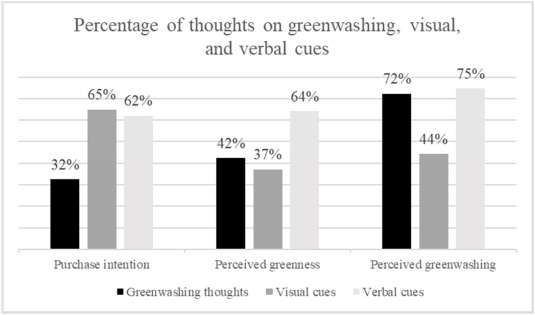

Fig. 5. Percentage of thoughts on greenwashing, visual, and verbal cues across conditions (Study 2).

##### 4.2.2.1. Greenwashing thoughts

There was a statistically significant association between condition and greenwashing thoughts, χ<sup>2</sup>(2) = 26.14, *p* < 0.001, Cramer’s V = 0.339. The number of participants with greenwashing thoughts was about equal in the purchase intention and perceived greenness conditions, but up to twice as large in the greenwashing condition (see Table B2). This provides partial support for H4 because participants in the purchase intention condition indeed had fewer greenwashing thoughts than in the greenwashing condition, but a comparable number of greenwashing thoughts as in the greenness condition.

##### 4.2.2.2. Visual and verbal cues

There was a statistically significant association between condition and visual cues, χ<sup>2</sup> (2) = 12.10, *p* = 0.002, Cramer’s V = 0.230. Results show that participants mentioned shared visual cues more often when asked for purchase intention than when asked for perceived greenness or greenwashing, in support of H5a (see Table B3). In contrast, there was no statistically significant association between condition and verbal cues, χ<sup>2</sup>(2) = 3.22, *p* = 0.200, Cramer’s V = 0.119. Thus, H5b stating that participants will mention distinct verbal cues less often when asked for purchase intention than when asked for perceived greenness or greenwashing was not supported (see Table B4).

#### 4.2.3. Explicit categorization task

##### 4.2.3.1. Response time

In categorizing the greenwashed product, a Kruskal-Wallis H test showed a statistically significant difference for median response time between conditions, χ<sup>2</sup>(2) = 7.167, *p* = 0.028. Based on adjusted p-values, post hoc analysis with a Bonferroni correction revealed a statistically significant difference in median response time between purchase intention (8.21) and perceived greenness (6.67, *p* = 0.048) and a marginally significant difference between purchase intention (8.21) and perceived greenwashing (6.36, *p* = 0.072). Therefore, H6a stating that participants will need more time to categorize the greenwashed product when asked for purchase intention than when asked for perceived greenness or greenwashing was partially supported (see Table B5).

##### 4.2.3.2. Categorization

The greenwashed and honest green products were correctly categorized by 138 participants (60.5%), respectively, while the non-green product was correctly categorized by 186 participants (81.6%). A chi-square test of independence between condition and the correct categorization of the greenwashed product (0 = incorrect, 1 = correct) finds no statistically significant association, χ<sup>2</sup>(2) = 1.55, *p* = 0.461, Cramer’s V = 0.082. Thus, H6b stating that participants will more often wrongly categorize the greenwashed product when asked for purchase intention than when asked for perceived greenness or greenwashing was not supported (see Table B6).

### 4.3. Discussion of Study 2

Study 2 replicates the overall results of Study 1a and sheds light on the cognitive process that influences when consumers can identify greenwashing. Three out of five different outcome variables support the idea that consumers' limited ability to identify greenwashing when solely asked for purchase intention may lie in their use of only two category representations (green and non-green) and not accessing a third greenwashed category.

First, participants reported fewer greenwashing thoughts in the purchase intention condition compared to the greenwashing condition (but not the greenness condition). Second, participants mentioned visual cues more often in the purchase intention condition, while no significant difference between conditions was found for verbal cues. This aligns with extant research demonstrating the power of visual green(washing) cues (Parguel et al., 2015), for example, when positive nature evoking images could override any rational greenwashing perceptions based on claims through an affective persuasion mechanism (Schmuck et al., 2018), thus misleading consumers. Notably, the reliance on visual over verbal cues in the purchase intention condition occurred in an experimental context with rather limited cognitive load and will most likely be exacerbated in real shopping contexts in which consumers are confronted with a higher product variety and temporal pressure (Granato et al., 2022; Magnier & Schoormans, 2015). Third, participants indeed needed more time to categorize the greenwashed product in the purchase intention condition. This further supports the idea that participants may not have thought of greenwashing before and, thus, needed more time to access this additional category representation (Loken et al., 2008). Interestingly, there was no significant difference in participants' correct categorization of the greenwashed product across conditions. This may be explained by the longer response time in the purchase intention condition, which may have helped participants to arrive at a correct categorization about equally often as in the other conditions once the third greenwashed category was accessed.

## 5. General discussion

The aim of this research was to empirically test consumers' ability to identify greenwashing in different products. Two experimental studies using four samples show that this ability largely depends on what consumers pay attention to during [product evaluation](https://www.sciencedirect.com/topics/agricultural-and-biological-sciences/product-evaluation). An overview of all tested hypotheses and the respective results across all studies is provided in Table 1.

Table 1. Summary of hypotheses-testing.

| Hypotheses | Study 1a | Study 1b | Study 1c | Study 2 |
| --- | --- | --- | --- | --- |
| H1. Consumers' purchase intention is higher for an honest green and a non-green product than for a greenwashed product. | Not supported | Not supported | Partially supported | Not supported |
| H2. Consumers' perceived greenness is higher for an honest green product than for a greenwashed and a non-green product. | Supported | Partially supported | Partially supported | Supported |
| H3. Consumers' perceived greenwashing is higher for a greenwashed product than for an honest green and a non-green product. | Supported | Supported | Supported | Supported |
| H4. When consumers evaluate purchase intentions (vs. perceived greenness and greenwashing), they will report fewer greenwashing thoughts. | n.a. | n.a. | n.a. | Partially supported |
| H5. When consumers evaluate purchase intentions (vs. perceived greenness and greenwashing), they will mention (a) shared visual cues more often and (b) distinct verbal cues less often. | n.a. | n.a. | n.a. | H5a supported, H5b not supported |
| H6. When consumers evaluate purchase intentions (vs. perceived greenness and greenwashing), they will (a) need more time to categorize the greenwashed product and (b) more often wrongly categorize it. | n.a. | n.a. | n.a. | H6a partially supported, H6b not supported |

When participants were asked for their *purchase intentions*, they about equally preferred the honest green and greenwashed low-involvement products and even preferred the greenwashed over the non-green low-involvement products. This suggests that participants have not recognized the greenwashed product as such when evaluating their purchase intentions. Three out of five outcome variables in Study 2 support the idea that this phenomenon appears when consumers only draw on two categories (green and non-green) instead of three (green, non-green, and greenwashed): When asked for their purchase intentions, consumers seem to barely think of greenwashing as measured by their reported greenwashing thoughts. Instead, they seem to be trapped by overly considering the shared green look-and-feel of the green products which is driven by a focus on visual as opposed to verbal green(washing) cues. In addition, participants needed longer to categorize the greenwashed product which further indicates that a third greenwashed product category still needed to be accessed.

When participants were asked for their *perceived greenness*, this seemed to help them identify greenwashing in the strength-related low-involvement product (toilet cleaner), but not in the products for which environmental friendliness seems to be desirable (hand cream, smartphone). For the latter two, participants mistakenly perceived the greenwashed products to be similarly green as their honest green counterparts. Thus, simply moving consumers' focus to consider a product’s greenness seems not yet sufficient to successfully detect greenwashing. Only when participants were asked for their *perceived greenwashing*, there appear to be no doubts about the greenwashed product: Across all studies, the greenwashed product was identified as such. This is backed by Study 2 which shows by far the largest number of greenwashing thoughts in the greenwashing condition compared to the other two conditions.

Embedding these findings into categorization theory, categories indeed may be activated through priming, which increases the likelihood of their later use (Herr, 1989; Loken et al., 2008; Macrae et al., 1995). In the context of green products, extant research suggests that environmental schemas can already be activated by viewing an isolated environmental product cue, such as eco-labels or green color, triggering environment-related thoughts (Pancer et al., 2017). The present research supports the idea that such an *implicit* category activation based on green(washed) product cues may be sufficient for consumers to dichotomously categorize a product as either green or non-green on a very basic level of categorization (Rosch, 1978). However, the present findings further imply that even multiple green(washed) product cues may be insufficient in protecting consumers from being deceived. The results suggest that *explicit* category activation (i.e., asking consumers to evaluate products with regard to perceptions of greenness and greenwashing) helps consumers focus their attention on the cues distinguishing the honest green and greenwashed product. In the words of Eleanor Rosch (1978): “… in fact, objects may be first seen or recognized as members of their basic category, and … only with the aid of additional processing can they be identified as members of their superordinate or subordinate category” (pp. 9–10). In our case, participants may have progressed from accessing the two basic categories of non-green and green products to additionally consider a greenwashed category, which can be considered as subordinated to the green category. Notably, simply asking for consumers' perceived greenness was not always sufficient to meaningfully distinguish between the two green-looking products just yet. Following the logic proposed by Pancer et al. (2017), responding to questions on perceived greenness (environmental or green category prime) activated an environmental friendly schema that could have led consumers to search for green cues in support of a categorization as honest green product, potentially exacerbating the distinction in only the two basic categories. It is conceivable that only when participants answered questions on perceived greenwashing (greenwashing category prime), this activated a greenwashing schema which made them pay attention to the distinct greenwashing cues and enabled them to identify the greenwashed product as such.

### 5.1. Implications for theory and research

This research contributes to the literature on consumers' perceptions of products with green(washed) cues in two ways. First, we directly examine consumers' ability to identify greenwashing across two experimental studies and provide empirical evidence that consumers sometimes recognize greenwashing (i.e., when they are primed) and sometimes not. This is relevant to consider in existing theoretical frameworks that involve perceived greenwashing (e.g., Chen & Chang, 2013; Schmuck et al., 2018; Szabo & Webster, 2021) because the effect of perceived greenwashing on various consumer responses will diminish if consumers actually do not recognize greenwashing. This aligns with prior research that has found similar evidence for consumers being deceived by misleading advertising (Ende et al., 2023; Fernandes et al., 2020; Schmuck et al., 2018). Notably, some studies tend to lack a holistic approach to manipulate greenwashing and compared only specific verbal (e.g., Iovino et al., 2023; Newell et al., 1998) or visual cues (e.g., Ende et al., 2023; Parguel et al., 2015), respectively. By combining multiple different visual and verbal cues reflected in executional and claim greenwashing (Matthes, 2019; Pancer et al., 2017), and by operationalizing the specific cues differently across three products varying in involvement and strength/gentleness (Schmuck et al., 2018), the present research offers comparably more generalizability of the phenomenon.

Second, extant research on misleading green advertising has drawn on [attribution theory](https://www.sciencedirect.com/topics/social-sciences/attribution-theory) (Iovino et al., 2023), persuasion knowledge (Fernandes et al., 2020), the affect–reason–involvement model (Schmuck et al., 2018), and the elaboration likelihood model (Parguel et al., 2015), among others. In contrast, this research applied categorization theory to offer a different theoretical account to explain greenwashing perceptions (Ende et al., 2023). Specifically, we provide initial evidence for the influence of activating categories through priming on consumers' ability to identify greenwashing: Without an explicit greenwashing category prime, this ability seems to be inhibited because consumers merely think of two basic category representations (green and non-green) when evaluating products. This cognitive process can be altered by drawing consumers' attention from purchase intentions to consider how green(washed) they perceive a product (i.e., category prime). Notably, most extant research on green advertising that involves categorization theory has applied this theory to examine consumers' responses to green compared to non-green products (Gershoff & Frels, 2015; Lee et al., 2020; Pancer et al., 2017). The present research extends this work by adding a greenwashed product category to further differentiate between green-looking products of varying quality, with which consumers are increasingly confronted in daily life. To conclude, drawing on categorization theory to explain when consumers are able to identify greenwashing contributes to a better understanding of consumers' perceptions and responses to green(washed) products.

### 5.2. Implications for practice

By empirically testing the extent to which consumers are able to identify greenwashing, this research challenges the validity of various practical recommendations grounded in an assumption that consumers can do so (Newell et al., 1998; Pancer et al., 2017; Simula & Lehtimäki, 2009). The present findings show that consumers can identify greenwashing if they are primed to do so, but not necessarily otherwise. Thus, in the absence of a greenwashing category prime, two possible consequences are implied from a corporate view: First, companies pretending to be green may benefit when consumers mistake a greenwashed product as honest green. As reflected in the results, this can still happen even when a green category prime is present. Second, when consumers think of an honest green product to be greenwashed, they may unintentionally penalize genuine companies that actually try to improve their sustainability performance. Notably, even when the greenwashing category prime was present, findings showed that the honest green products were perceived as greenwashed to a certain degree. Overall, both errors are neither in the interest of genuine companies nor of public policymakers as they can undermine markets for honest green products (Chen & Chang, 2013; Fernandes et al., 2020). Therefore, both stakeholder groups have an interest in better enabling consumers to identify greenwashing.

For genuine companies, it is advisable to use specific, true, and relevant green claims combined with official eco-labels to make categorization of their products into the honest green category as easy and unambiguous as possible (Lee et al., 2020; Pancer et al., 2017). This approach receives support from public policy that only recently proposed the Green Claims Directive, which intends to penalize the use of unsubstantiated voluntary environmental claims and labels in the [European Union](https://www.sciencedirect.com/topics/social-sciences/european-community) (European Commission, 2023). If the directive is to be implemented successfully, greenwashed products ideally would be crowded out in the long run. In the meantime, while green products still come in honest green and greenwashed forms, extant research has emphasized the importance of educating consumers to develop a thorough understanding about what makes green cues valid or misleading (Fernandes et al., 2020; Newell et al., 1998). While this is an important endeavor to combat greenwashing, an interim route may be more time-efficient and easy to apply compared to large-scale regulatory and educational measures: The present findings highlight the important role of category activation in directing consumers' attention to the possibility of greenwashing. By asking consumers to evaluate products with regard to their perceived greenwashing, the greenwashed product category could be activated through priming, which was sufficient for consumers to detect greenwashing. How exactly the greenwashed category can be meaningfully activated in purchase contexts still needs to be explored, ideally in conjunction with practitioners. Overall, developing alternative measures to nudge consumers to critically reflect on green(washed) cues can provide a promising avenue to counter the undesired effects of greenwashing.

### 5.3. Limitations and future research

Several limitations that future research could address should be noted. First, although participants were able to distinguish the two green-looking products when asked for perceived greenwashing, the honest green product was also perceived to be greenwashed to a certain extent. This indicates that reminding consumers of the possibility of greenwashing can backfire and lead genuine companies to refrain from promoting their honest green products as green to avoid potential accusations of greenwashing (Falchi et al., 2022). Therefore, more research on how consumers respond to the initially excluded product category with a low [green marketing](https://www.sciencedirect.com/topics/social-sciences/green-marketing) level but high product sustainability (i.e., green muter) seems worthwhile (Acuti et al., 2022; Szabo & Webster, 2021).

Second, future research could also account for the fact that what is perceived as green(washing) may be very subjective (Lyon & Montgomery, 2015), meaning that the categories for honest green and greenwashed products may be represented differently among individuals. It is conceivable that not all consumers may follow the prototype view of category representation adopted in this research, where categories were composed of abstract prototypical cues. Instead, consumers may use specific stored product examples of a category, depicting the exemplar view of category representation (Loken et al., 2008). Thus, while this research defined prototypical green(washed) cues upfront based on prior studies, future research could use qualitative methods to learn more about the categories and cues with which green(washed) products are represented in individual’s minds.

Third, the findings of this research are limited to environmental cues which were studied in a German context. Notably, extant research suggests that German consumers may have more environmental knowledge than other cultures (e.g., Schmuck et al., 2018). Therefore, the German samples provide a conservative context to examine consumers' ability to identify greenwashing (compared to countries less knowledgeable in sustainability topics).<sup>3</sup> Nevertheless, future research could extend this design to include social cues (which currently are also not regulated in the Green Claims Directive) as well as to different cultural contexts to test whether the extant findings hold.

Finally, we acknowledge that the findings on consumers' limited ability to identify greenwashing could have occurred because this research did not examine actual behavior. It is conceivable that consumers may be more cognitively involved and thus access a greenwashed category if they were faced with real behavioral choices. Therefore, if a useful way to involve a real greenwashed product was found, it would be desirable to replicate the results in an even more realistic setting where consumers' responses also entail behavioral consequences (such as an actual purchase).

## Research ethics

Informed consent was obtained from all individual participants included in the studies.

## Funding statement

This research did not receive any specific grant from funding agencies in the public, commercial, or not-for-profit sectors.

## CRediT authorship contribution statement

**Stefanie Fella:** Writing – review & editing, Writing – original draft, Visualization, Validation, Supervision, Software, Project administration, Methodology, Investigation, Formal analysis. **Elena Bausa:** Writing – review & editing, Software, Investigation, Formal analysis, Conceptualization.

## Acknowledgements

The authors of this research would like to thank the following people who were affiliated with the Heinrich Heine University Düsseldorf during this research endeavor: Hanna Misch and Antonio Jimenez Luksch for their support in creating the stimulus material and in collecting data for Study 1b and Study 1c, as well as Katharina Petsch and Bennet Stubbe for their help in the coding procedure for Study 2. We would also like to thank two anonymous reviewers for their helpful comments.

## Supplementary data

The following is the Supplementary data to this article:[Download: Download Word document (64KB)](https://ars.els-cdn.com/content/image/1-s2.0-S0272494424000549-mmc1.docx)

Multimedia component 1.

## Appendix A. Studies 1a-c

Table A1. Product stimuli for toilet cleaner (Study 1a) based on extant green product categories (Simula & Lehtimäki, 2009; Szabo & Webster, 2021).

| Product | Honest green product | Greenwashed product | Non-green product |
| --- | --- | --- | --- |
| **Original stimuli** presented in German, see translated cues below |  |  |  |
| **Claim 1** | *Specific:* “Formula without microplastics” | *Vague:* “Does something good for the environment” | “Long-lasting freshness” |
| **Claim 2** | *True:* “Surfactants based on renewable raw materials” | *False:* “More environmentally friendly than pure water” | “Powerful against dirt and limescale” |
| **Claim 3** | *Relevant:* “99.9% biodegradable” | *Irrelevant:* “99.9% without formaldehyde”<sup>c</sup> | “Eliminates 99.9% of bacteria” |
| **Color** | Green | Green | Orange |
| **Imagery** | Leaves | Leaves | Bubbles of soap |
| **Eco-labels** | Official European eco-label<sup>a</sup> and V-Label<sup>b</sup> | Fake labels stating “eco-product” and “vegan” | None |

Note.

<sup>a</sup> The European eco-label signals that a product or a service has a lower environmental impact than comparable ones (European Union, 2009).

<sup>b</sup> The European V-Label is one of the two most widespread labels for vegan products in the European Union (Stremmel et al., 2022).

<sup>c</sup> This represents an irrelevant claim because declaring the carcinogenic preservative formaldehyde as ingredient is required by law for finished products in which the concentration exceeds 0.05% (SCCNFP, 2002). For reasons of consistency and applicability with regard to the numerical claims for the honest green and non-green product the numeric 99.9% was used.

Table A2. Product stimuli for hand cream (Study 1b) based on extant green product categories (Simula & Lehtimäki, 2009; Szabo & Webster, 2021).

| Product | Honest green product | Greenwashed product | Non-green product |
| --- | --- | --- | --- |
| **Original stimuli** presented in German, see translated cues below |  |  |  |
| **Claim 1** | *Specific:* “Ingredients from controlled organic cultivation” | *Vague:* “Does something good for the environment” | “Nourishes and protects your hands” |
| **Claim 2** | *True:* “Formula without microplastics” | *False:* “No ecological footprint” | “Long lasting moisturizing care” |
| **Claim 3** | *Relevant:* “Certified natural cosmetics” | *Irrelevant:* “Without animal testing”<sup>c</sup> | “Quickly absorbed” |
| **Color** | Green | Green | Orange |
| **Imagery** | Grass | Grass | Hand |
| **Eco-labels** | Natrue label<sup>a</sup> and official Vegan Trademark<sup>b</sup> | Fake labels stating “natural beauty” and “vegan” | None |

Note.

<sup>a</sup> The Natrue label is a leading certification standard for natural and organic cosmetic products (Bozza et al., 2022).

<sup>b</sup> The Vegan Trademark is one of the two most widespread labels for vegan products in the European Union (Stremmel et al., 2022).

<sup>c</sup> This represents an irrelevant claim because animal testing of cosmetic products has been banned in the European Union (Bozza et al., 2022).

Table A3. Product stimuli for smartphone (Study 1c) based on extant green product categories (Simula & Lehtimäki, 2009; Szabo & Webster, 2021).

Product

Honest green product

Greenwashed product

Non-green product

**Original stimuli** presented in German, see translated cues below

[figure not shown]

[figure not shown]

**Claim 1**

*Specific:* “Modular design - Components can be reused after use”

*Vague:* “Sustainable design - Does something good for the environment”

“Modern design – The perfect combination of form and function”

**Claim 2**

*True:* “Case made from 100% recycled material”

*False:* “100% biodegradable”

“100% charged within one hour”

**Claim 3**

*Relevant:* “Free repair service for a long lifetime”

*Irrelevant:* “Does not contain banned chemical substances”

“High-resolution cameras with optical zoom”

**Color**

Green

Green

Blue

**Imagery**

Natural elements

Natural elements

Technical elements

**Eco-labels**

Official German Blue Angel<sup>a</sup> and European eco-label<sup>b</sup>

Fake labels stating “angel product” and “eco-product”

None

Note.

<sup>a</sup> The German Blue Angel label represents the oldest eco-label worldwide and addresses environmental and health-related aspects of products and services (Rubik et al., 2022).

<sup>b</sup> The European eco-label signals that a product or a service has a lower environmental impact than comparable ones (European Union, 2009).

Table A4. Overview of scales used to measure constructs in Studies 1a-c.

| Construct Empty Cell | Items Empty Cell | Cronbach’s alpha Toilet cleaner (*N* = 153) | Cronbach’s alpha Hand cream (*N* = 157) | Cronbach’s alpha Smartphone (*N* = 162) |
| --- | --- | --- | --- | --- |
| **Purchase intention** *(*Bian & Forsythe, 2012*; based on* Dodds et al., 1991*)* | If I were going to purchase a [product]<sup>a</sup>, I would consider buying this product. If I were going to buy a [product], the likelihood I would purchase this product is high. My willingness to b… | α<sub>hg</sub> = 0.962 α<sub>gw</sub> = 0.967 α<sub>ng</sub> = 0.962 | α<sub>hg</sub> = 0.939 α<sub>gw</sub> = 0.933 α<sub>ng</sub> = 0.947 | α<sub>hg</sub> = 0.966 α<sub>gw</sub> = 0.977 α<sub>ng</sub> = 0.976 |
| **Perceived greenness** *(*Gershoff & Frels, 2015*)* | This product deserves to be labeled ‘environmentally friendly’. Purchasing this product is a good environmental choice. A person who cares about the environment would be likely to buy this product. Ho… | α<sub>hg</sub> = 0.940 α<sub>gw</sub> = 0.957 α<sub>ng</sub> = 0.914 | α<sub>hg</sub> = 0.913 α<sub>gw</sub> = 0.936 α<sub>ng</sub> = 0.905 | α<sub>hg</sub> = 0.946 α<sub>gw</sub> = 0.941 α<sub>ng</sub> = 0.953 |
| **Perceived greenwashing** *(*Chen & Chang, 2013; Schmuck et al., 2018*)* | The text shown on this product is misleading in regard to its environmental features. The visuals or graphics pictured on this product are misleading in regard to its environmental features. This prod… | α<sub>hg</sub> = 0.936 α<sub>gw</sub> = 0.929 α<sub>ng</sub> = 0.908 | α<sub>hg</sub> = 0.920 α<sub>gw</sub> = 0.940 α<sub>ng</sub> = 0.906 | α<sub>hg</sub> = 0.931 α<sub>gw</sub> = 0.938 α<sub>ng</sub> = 0.948 |

*Note.* All but one item were measured using 7-point Likert scales from 1 = strongly disagree to 7 = strongly agree. hg = honest green, gw = greenwashed, ng = non-green.

<sup>a</sup> Insert toilet cleaner, hand cream, or smartphone as product.

<sup>b</sup> This item was answered on a 7-point Likert scale from 1 = not at all environmentally friendly to 7 = extremely environmentally friendly.

## Appendix B. Study 2

Table B1. Details on the coding procedure for Study 2.

Codes

Responses …

Examples (respondent number) (translated from German)

**Group: Greenwashing thoughts**

0

No

- -

  do not refer to sustainability
- -

  I would buy that (R10)
- -

  Appearance not appealing (R15)
- -

  refer positively to sustainability
- -

  Environmentally friendly (R18)
- -

  Green is “in” (R10)
- -

  refer negatively to sustainability
- -

  Bad for the environment (R10)

1

Yes

- -

  indicate mistrust or doubts such that participants question the product's sustainability
- -

  Possibly not entirely credible (R3)
- -

  Is it possible to verify the claims? (R4)
- -

  How can a product be more environmentally friendly than water? (R51)
- -

  clearly indicate greenwashing by concluding that a product is deceptive
- -

  Misleading (R128)
- -

  False claim on the label (R66)
- -

  Looks like greenwashing (R217)
- -

  “Better for the environment than water” is a lie (R58)

**Group: Visual cues**<sup>**a, c**</sup>

0

No

- -

  do not indicate visual cues at all
- -

  Anyone can claim to be environmentally friendly (R9)
- -

  if “green” is used as synonym to “sustainable” it does not count as visual cue in terms of color
- -

  These products advertised as "green" are just annoying (R133)

1

Yes

- -

  mention visual cues on a general, abstract level
- -

  Pleasant appearance (R82)
- -

  Nice color (R55)
- -

  refer to specific visual cues
- -

  Green color (R36)
- -

  What do images of leaves have to do with toilet cleaning? (R28)

**Group: Verbal cues**<sup>**b, c**</sup>

0

No

- -

  do not indicate verbal cues at all
- -

  Looks sustainable (R54)
- -

  Do not know this product (R101)

1

Yes

- -

  mention verbal cues on a general, abstract level
- -

  Exaggerated description of the product (R141)
- -

  I cannot judge whether the information is correct (R169)
- -

  summarizes specific statements
- -

  Without harmful chemistry (R134)
- -

  Contains surfactants (R47)
- -

  refer to keywords from specific verbal cues as stated in Tables A1–A3
- -

  No microplastic, very good (R56)

*Note.* Across all responses from one participant, the highest numerical code denotes the final code within one code group (i.e., greenwashing thoughts). If participants mentioned more than one thought related to the same numerical code, this was counted only once.

<sup>a</sup> Labels were coded as zero for visual cues because they differed between the green products. This counters the idea that visual cues would inhibit participants from distinguishing between the green products (as opposed to color and imagery).

<sup>b</sup> References to the brand names (Clean green, Clean right) were coded as zero for verbal cues because they did *not* differ between the green products. This counters the idea that verbal cues would help participants distinguish between the green products (as opposed to the three different claims).

<sup>c</sup> Responses solely referring to the packaging itself (e.g., its form, material, recyclability etc.) were coded as zero because packaging features were not part of the experiment and not manipulated. If responses referred to visual or verbal cues *on the* packaging, this was coded as outlined above.

Table B2. Frequency of greenwashing thoughts across conditions.

| Greenwashing thoughts | Empty Cell | Purchase intention | Perceived greenness | Perceived greenwashing |
| --- | --- | --- | --- | --- |
| No | Frequencies | 48<sub>a</sub> | 45<sub>a</sub> | 22<sub>b</sub> |
|  | Proportion within condition | 67.6% | 57.7% | 27.8% |
|  | Adjusted residual | 3.5 | 1.6 | −5.0 |
| Yes | Frequencies | 23<sub>a</sub> | 33<sub>a</sub> | 57<sub>b</sub> |
|  | Proportion within condition | 32.4% | 42.3% | 72.2% |
|  | Adjusted residual | −3.5 | −1.6 | 5.0 |

*Note.* Columns sharing the same superscript letter are not significantly different at the 0.05 level (Crosstabs with pairwise z-test Bonferroni corrected).

Table B3. Frequency of shared visual cues across conditions.

| Visual cues mentioned (color and imagery) | Empty Cell | Purchase intention | Perceived greenness | Perceived greenwashing |
| --- | --- | --- | --- | --- |
| No | Frequencies | 25<sup>a</sup> | 49<sup>b</sup> | 44<sup>b</sup> |
|  | Proportion within condition | 35.2% | 62.8% | 55.7% |
|  | Adjusted residual | −3.4 | 2.4 | 0.9 |
| Yes | Frequencies | 46<sup>a</sup> | 29<sup>b</sup> | 35<sup>b</sup> |
|  | Proportion within condition | 64.8% | 37.2% | 44.3% |
|  | Adjusted residual | 3.4 | −2.4 | −0.9 |

*Note.* Columns sharing the same superscript letter are not significantly different at the 0.05 level (Crosstabs with pairwise z-test Bonferroni corrected).

Table B4. Frequency of distinct verbal cues across conditions.

| Verbal cues mentioned (three claims) | Empty Cell | Purchase intention | Perceived greenness | Perceived greenwashing |
| --- | --- | --- | --- | --- |
| No | Frequencies | 27<sup>a</sup> | 28<sup>a</sup> | 20<sup>a</sup> |
|  | Proportion within condition | 38.0% | 35.9% | 25.3% |
|  | Adjusted residual | 1.1 | 0.7 | −1.8 |
| Yes | Frequencies | 44<sup>a</sup> | 50<sup>a</sup> | 59<sup>a</sup> |
|  | Proportion within condition | 62.0% | 64.1% | 74.7% |
|  | Adjusted residual | −1.1 | −0.7 | 1.8 |

*Note.* Columns sharing the same superscript letter are not significantly different at the 0.05 level (Crosstabs with pairwise z-test Bonferroni corrected).

Table B5. Pairwise comparison of condition for response time to categorize the greenwashed product.

| Condition 1 | Condition 2 | Test statistic | Std. error | Std. test statistic | Sig. | Adj. sig.<sup>a</sup> |
| --- | --- | --- | --- | --- | --- | --- |
| Perc. greenness | Perc. greenwashing | −1.712 | 10.529 | −0.163 | 0.871 | 1.000 |
| Perc. greenness | Purchase intention | 26.071 | 10.820 | 2.410 | 0.016 | 0.048 |
| Perc. greenwashing | Purchase intention | 24.359 | 10.787 | 2.258 | 0.024 | 0.072 |

*Note.* Each row tests the null hypothesis that Condition 1 and Condition 2 distributions are the same.

Asymptotic significances (2-sided tests) are displayed. The significance level is 0.050.

<sup>a</sup> Significance values have been adjusted by the Bonferroni correction for multiple tests.

Table B6. Frequency of correct categorization of greenwashed product across conditions.

| Categorization of greenwashed product | Empty Cell | Purchase intention | Perceived greenness | Perceived greenwashing |
| --- | --- | --- | --- | --- |
| Incorrect | Frequencies | 27<sup>a</sup> | 35<sup>a</sup> | 28<sup>a</sup> |
|  | Proportion within condition | 38.0% | 44.9% | 35.4% |
|  | Adjusted residual | −0.3 | 1.2 | −0.9 |
| Correct | Frequencies | 44<sup>a</sup> | 43<sup>a</sup> | 51<sup>a</sup> |
|  | Proportion within condition | 62.0% | 55.1% | 64.6% |
|  | Adjusted residual | 0.3 | −1.2 | 0.9 |

*Note.* Columns sharing the same superscript letter are not significantly different at the 0.05 level (Crosstabs with pairwise z-test Bonferroni corrected).

## References

1. Acuti et al., 2022

   D. Acuti, M. Pizzetti, S. Dolnicar

   When sustainability backfires: A review on the unintended negative side‐effects of product and service sustainability on consumer behavior

   Psychology and Marketing, 39 (10) (2022), pp. 1933-1945, 10.1002/mar.21709

   [View in Scopus](https://www.scopus.com/inward/record.url?eid=2-s2.0-85133630157&partnerID=10&rel=R3.0.0)Google Scholar
2. Atkinson and Rosenthal, 2014

   L. Atkinson, S. Rosenthal

   Signaling the green sell: The influence of eco-label source, argument specificity, and product involvement on consumer trust

   Journal of Advertising, 43 (1) (2014), pp. 33-45, 10.1080/00913367.2013.834803

   [View in Scopus](https://www.scopus.com/inward/record.url?eid=2-s2.0-84893947427&partnerID=10&rel=R3.0.0)Google Scholar
3. Bian and Forsythe, 2012

   Q. Bian, S. Forsythe

   Purchase intention for luxury brands: A cross cultural comparison

   Journal of Business Research, 65 (10) (2012), pp. 1443-1451, 10.1016/j.jbusres.2011.10.010

   [View PDF](https://www.sciencedirect.com/science/article/pii/S0148296311003547/pdfft?md5=8a54e6c4237da6a26706c1ba6c4cb55c&pid=1-s2.0-S0148296311003547-main.pdf)[View article](https://www.sciencedirect.com/science/article/pii/S0148296311003547)[View in Scopus](https://www.scopus.com/inward/record.url?eid=2-s2.0-84864932843&partnerID=10&rel=R3.0.0)[Google Scholar](https://scholar.google.com/scholar_lookup?title=Purchase%20intention%20for%20luxury%20brands%3A%20A%20cross%20cultural%20comparison&publication_year=2012&author=Q.%20Bian&author=S.%20Forsythe)
4. Bozza et al., 2022

   A. Bozza, C. Campi, S. Garelli, E. Ugazio, L. Battaglia

   Current regulatory and market frameworks in green cosmetics: The role of certification

   Sustainable Chemistry and Pharmacy, 30 (2022), Article 100851, 10.1016/j.scp.2022.100851

   [View PDF](https://www.sciencedirect.com/science/article/pii/S2352554122002558/pdfft?md5=1d59162aa7e39afc952c4b24aaba379f&pid=1-s2.0-S2352554122002558-main.pdf)[View article](https://www.sciencedirect.com/science/article/pii/S2352554122002558)[View in Scopus](https://www.scopus.com/inward/record.url?eid=2-s2.0-85139008965&partnerID=10&rel=R3.0.0)Google Scholar
5. Cacioppo and Petty, 1981

   J.T. Cacioppo, R.E. Petty

   Social psychological procedures for cognitive response assessment: The thought-listing technique

   T.V. Merluzzi, C.R. Glass, M. Genest (Eds.), Cognitive assessment, Guilford Press, New York (1981), pp. 309-342

   Google Scholar
6. Carlson et al., 1993

   L. Carlson, S.J. Grove, N. Kangun

   A content analysis of environmental advertising claims: A matrix method approach

   Journal of Advertising, 22 (3) (1993), pp. 27-39, 10.1080/00913367.1993.10673409

   [View in Scopus](https://www.scopus.com/inward/record.url?eid=2-s2.0-84952241601&partnerID=10&rel=R3.0.0)Google Scholar
7. Chen and Chang, 2013

   Y.-S. Chen, C.-H. Chang

   Greenwash and green trust: The mediation effects of green consumer confusion and green perceived risk

   Journal of Business Ethics, 114 (3) (2013), pp. 489-500, 10.1007/s10551-012-1360-0

   Google Scholar
8. Dodds et al., 1991

   W.B. Dodds, K.B. Monroe, D. Grewal

   Effects of price, brand, and store information on buyers’ product evaluations

   Journal of Marketing Research, 28 (3) (1991), pp. 307-319, 10.2307/3172866

   Google Scholar
9. Ende et al., 2023

   L. Ende, M.-A. Reinhard, L. Göritz

   Detecting greenwashing! The influence of product colour and product price on consumers' detection accuracy of faked bio-fashion

   Journal of Consumer Policy, 46 (2) (2023), pp. 155-189, 10.1007/s10603-023-09537-8

   [View in Scopus](https://www.scopus.com/inward/record.url?eid=2-s2.0-85151521180&partnerID=10&rel=R3.0.0)Google Scholar
10. European Commission, 2023

    European Commission

    Green Claims Directive - proposal for a directive of the European Parliament and of the Council on substantiation and communication of explicit environmental claims

    (2023)

    COM(2023) 166 final [Retrieved 25.07.2023]

    https://environment.ec.europa.eu/publications/proposal-directive-green-claims_en

    Google Scholar
11. European Union, 2009

    European Union

    Regulation (EC) No 66/2010 of the European parliament and of the council of 25 November 2009 on the EU Ecolabel

    [Retrieved 02.09.2022]

    http://data.europa.eu/eli/reg/2010/66/oj (2009)

    Google Scholar
12. Falchi et al., 2022

    A. Falchi, G. Grolleau, N. Mzoughi

    Why companies might under‐communicate their efforts for sustainable development and what can be done?

    Business Strategy and the Environment, 31 (5) (2022), pp. 1938-1946, 10.1002/bse.2991

    [View in Scopus](https://www.scopus.com/inward/record.url?eid=2-s2.0-85123219496&partnerID=10&rel=R3.0.0)Google Scholar
13. Fernandes et al., 2020

    J. Fernandes, S. Segev, J.K. Leopold

    When consumers learn to spot deception in advertising: Testing a literacy intervention to combat greenwashing

    International Journal of Advertising, 39 (7) (2020), pp. 1115-1149, 10.1080/02650487.2020.1765656

    [View in Scopus](https://www.scopus.com/inward/record.url?eid=2-s2.0-85084985290&partnerID=10&rel=R3.0.0)Google Scholar
14. Gershoff and Frels, 2015

    A.D. Gershoff, J.K. Frels

    What makes it green? The role of centrality of green attributes in evaluations of the greenness of products

    Journal of Marketing, 79 (2015), pp. 97-110, 10.1509/jm.13.0303

    [View in Scopus](https://www.scopus.com/inward/record.url?eid=2-s2.0-84922011917&partnerID=10&rel=R3.0.0)Google Scholar
15. Geuens and Pelsmacker, 2017

    M. Geuens, P. de Pelsmacker

    Planning and conducting experimental advertising research and questionnaire design

    Journal of Advertising, 46 (1) (2017), pp. 83-100, 10.1080/00913367.2016.1225233

    [View in Scopus](https://www.scopus.com/inward/record.url?eid=2-s2.0-85010670270&partnerID=10&rel=R3.0.0)Google Scholar
16. Granato et al., 2022

    G. Granato, A.R. Fischer, H.C. van Trijp

    A meaningful reminder on sustainability: When explicit and implicit packaging cues meet

    Journal of Environmental Psychology, 79 (2022), Article 101724, 10.1016/j.jenvp.2021.101724

    [View PDF](https://www.sciencedirect.com/science/article/pii/S0272494421001778/pdfft?md5=83976e01fda4e47de031a73ddb1a0c04&pid=1-s2.0-S0272494421001778-main.pdf)[View article](https://www.sciencedirect.com/science/article/pii/S0272494421001778)[View in Scopus](https://www.scopus.com/inward/record.url?eid=2-s2.0-85119920159&partnerID=10&rel=R3.0.0)Google Scholar
17. Griskevicius et al., 2010

    V. Griskevicius, J.M. Tybur, B. van den Bergh

    Going green to be seen: Status, reputation, and conspicuous conservation

    Journal of Personality and Social Psychology, 98 (3) (2010), pp. 392-404, 10.1037/a0017346

    [View in Scopus](https://www.scopus.com/inward/record.url?eid=2-s2.0-77649158309&partnerID=10&rel=R3.0.0)Google Scholar
18. Hartmann et al., 2016

    P. Hartmann, V. Apaolaza, M. Eisend

    Nature imagery in non-green advertising: The effects of emotion, autobiographical memory, and consumer’s green traits

    Journal of Advertising, 45 (4) (2016), pp. 427-440, 10.1080/00913367.2016.1190259

    [View in Scopus](https://www.scopus.com/inward/record.url?eid=2-s2.0-84975528155&partnerID=10&rel=R3.0.0)Google Scholar
19. Hartmann and Apaolaza-Ibáñez, 2010

    P. Hartmann, V. Apaolaza-Ibáñez

    Beyond savanna: An evolutionary and environmental psychology approach to behavioral effects of nature scenery in green advertising

    Journal of Environmental Psychology, 30 (1) (2010), pp. 119-128, 10.1016/j.jenvp.2009.10.001

    [View PDF](https://www.sciencedirect.com/science/article/pii/S0272494409000759/pdfft?md5=86a8a1992fd45ff9a0cbfc32685e96aa&pid=1-s2.0-S0272494409000759-main.pdf)[View article](https://www.sciencedirect.com/science/article/pii/S0272494409000759)[View in Scopus](https://www.scopus.com/inward/record.url?eid=2-s2.0-76549123587&partnerID=10&rel=R3.0.0)Google Scholar
20. Herr, 1989

    P.M. Herr

    Priming price: Prior knowledge and context effects

    Journal of Consumer Research, 16 (1) (1989), pp. 67-75, 10.1086/209194

    [Google Scholar](https://scholar.google.com/scholar_lookup?title=Priming%20price%3A%20Prior%20knowledge%20and%20context%20effects&publication_year=1989&author=P.M.%20Herr)
21. Iovino et al., 2023

    R. Iovino, F. Testa, F. Iraldo

    Do consumers understand what different green claims actually mean? An experimental approach in Italy

    Journal of Advertising (2023), pp. 1-15, 10.1080/00913367.2023.2175279

    [View in Scopus](https://www.scopus.com/inward/record.url?eid=2-s2.0-85162706143&partnerID=10&rel=R3.0.0)Google Scholar
22. Kangun et al., 1991

    N. Kangun, L. Carlson, S.J. Grove

    Environmental advertising claims: A preliminary investigation

    Journal of Public Policy and Marketing, 10 (2) (1991), pp. 47-58, 10.1177/074391569101000203

    [Google Scholar](https://scholar.google.com/scholar_lookup?title=Environmental%20advertising%20claims%3A%20A%20preliminary%20investigation&publication_year=1991&author=N.%20Kangun&author=L.%20Carlson&author=S.J.%20Grove)
23. Kwon et al., 2023

    K. Kwon, J. Lee, C. Wang, V.S. Diwanji

    From green advertising to greenwashing: Content analysis of global corporations' green advertising on social media

    International Journal of Advertising (2023), pp. 1-24, 10.1080/02650487.2023.2208489

    Google Scholar
24. Lee et al., 2020

    E.J. Lee, J. Bae, K.H. Kim

    The effect of environmental cues on the purchase intention of sustainable products

    Journal of Business Research, 120 (2020), pp. 425-433, 10.1016/j.jbusres.2019.10.048

    [View PDF](https://www.sciencedirect.com/science/article/pii/S0148296319306319/pdfft?md5=9d50585be28ec9180b5a89170501a38d&pid=1-s2.0-S0148296319306319-main.pdf)[View article](https://www.sciencedirect.com/science/article/pii/S0148296319306319)[View in Scopus](https://www.scopus.com/inward/record.url?eid=2-s2.0-85076603055&partnerID=10&rel=R3.0.0)Google Scholar
25. Leonidou and Skarmeas, 2017

    C.N. Leonidou, D. Skarmeas

    Gray shades of green: Causes and consequences of green skepticism

    Journal of Business Ethics, 144 (2) (2017), pp. 401-415, 10.1007/s10551-015-2829-4

    [Google Scholar](https://scholar.google.com/scholar_lookup?title=Gray%20shades%20of%20green%3A%20Causes%20and%20consequences%20of%20green%20skepticism&publication_year=2017&author=C.N.%20Leonidou&author=D.%20Skarmeas)
26. Loken et al., 2008

    B. Loken, L.W. Barsalou, C. Joiner

    Categorization theory and research in consumer psychology

    Handbook of consumer psychology, Routledge (2008), 10.4324/9780203809570.ch5

    [Google Scholar](https://scholar.google.com/scholar_lookup?title=Categorization%20theory%20and%20research%20in%20consumer%20psychology&publication_year=2008&author=B.%20Loken&author=L.W.%20Barsalou&author=C.%20Joiner)
27. Luchs et al., 2010

    M.G. Luchs, R.W. Naylor, J.R. Irwin, R. Raghunathan

    The sustainability liability: Potential negative effects of ethicality on product preference

    Journal of Marketing, 74 (5) (2010), pp. 18-31, 10.1509/jmkg.74.5.18

    [View in Scopus](https://www.scopus.com/inward/record.url?eid=2-s2.0-77956708677&partnerID=10&rel=R3.0.0)Google Scholar
28. Lyon and Montgomery, 2015

    T.P. Lyon, A.W. Montgomery

    The means and end of greenwash

    Organization & Environment, 28 (2) (2015), pp. 223-249, 10.1177/1086026615575332

    [View in Scopus](https://www.scopus.com/inward/record.url?eid=2-s2.0-84936772105&partnerID=10&rel=R3.0.0)[Google Scholar](https://scholar.google.com/scholar_lookup?title=The%20means%20and%20end%20of%20greenwash&publication_year=2015&author=T.P.%20Lyon&author=A.W.%20Montgomery)
29. Macrae et al., 1995

    C.N. Macrae, G.V. Bodenhausen, A.B. Milne

    The dissection of selection in person perception: Inhibitory processes in social stereotyping

    Journal of Personality and Social Psychology, 69 (3) (1995), pp. 397-407, 10.1037//0022-3514.69.3.397

    [View in Scopus](https://www.scopus.com/inward/record.url?eid=2-s2.0-0029372120&partnerID=10&rel=R3.0.0)Google Scholar
30. Magnier and Schoormans, 2015

    L. Magnier, J. Schoormans

    Consumer reactions to sustainable packaging: The interplay of visual appearance, verbal claim and environmental concern

    Journal of Environmental Psychology, 44 (2015), pp. 53-62, 10.1016/j.jenvp.2015.09.005

    [View PDF](https://www.sciencedirect.com/science/article/pii/S0272494415300347/pdfft?md5=34420d26ba7086be5f5ff26d7cbea4f3&pid=1-s2.0-S0272494415300347-main.pdf)[View article](https://www.sciencedirect.com/science/article/pii/S0272494415300347)[View in Scopus](https://www.scopus.com/inward/record.url?eid=2-s2.0-84942794778&partnerID=10&rel=R3.0.0)Google Scholar
31. Matthes, 2019

    J. Matthes

    Uncharted territory in research on environmental advertising: Toward an organizing framework

    Journal of Advertising, 48 (1) (2019), pp. 91-101, 10.1080/00913367.2019.1579687

    [View in Scopus](https://www.scopus.com/inward/record.url?eid=2-s2.0-85064077453&partnerID=10&rel=R3.0.0)[Google Scholar](https://scholar.google.com/scholar_lookup?title=Uncharted%20territory%20in%20research%20on%20environmental%20advertising%3A%20Toward%20an%20organizing%20framework&publication_year=2019&author=J.%20Matthes)
32. Meyvis and van Osselaer, 2018

    T. Meyvis, S.M.J. van Osselaer

    Increasing the power of your study by increasing the effect size

    Journal of Consumer Research, 44 (5) (2018), pp. 1157-1173, 10.1093/jcr/ucx110

    [View in Scopus](https://www.scopus.com/inward/record.url?eid=2-s2.0-85041495515&partnerID=10&rel=R3.0.0)[Google Scholar](https://scholar.google.com/scholar_lookup?title=Increasing%20the%20power%20of%20your%20study%20by%20increasing%20the%20effect%20size&publication_year=2018&author=T.%20Meyvis&author=S.M.J.%20van%20Osselaer)
33. Newell et al., 1998

    S.J. Newell, R.E. Goldsmith, E.J. Banzhaf

    The effect of misleading environmental claims on consumer perceptions of advertisements

    Journal of Marketing Theory and Practice, 6 (2) (1998), pp. 48-60, 10.1080/10696679.1998.11501795

    Google Scholar
34. Pancer et al., 2017

    E. Pancer, L. McShane, T.J. Noseworthy

    Isolated environmental cues and product efficacy penalties: The color green and eco-labels

    Journal of Business Ethics, 143 (1) (2017), pp. 159-177, 10.1007/s10551-015-2764-4

    [View in Scopus](https://www.scopus.com/inward/record.url?eid=2-s2.0-85020389129&partnerID=10&rel=R3.0.0)Google Scholar
35. Parguel et al., 2015

    B. Parguel, F. Benoit-Moreau, C.A. Russell

    Can evoking nature in advertising mislead consumers? The power of ‘executional greenwashing’

    International Journal of Advertising, 34 (1) (2015), pp. 107-134, 10.1080/02650487.2014.996116

    [View in Scopus](https://www.scopus.com/inward/record.url?eid=2-s2.0-84922352838&partnerID=10&rel=R3.0.0)Google Scholar
36. Rosch, 1978

    E. Rosch

    Principles of categorization

    E. Rosch, B.B. Lloyd (Eds.), Cognition and categorization, Erlbaum, Hillsdale, NJ (1978)

    [Google Scholar](https://scholar.google.com/scholar_lookup?title=Principles%20of%20categorization&publication_year=1978&author=E.%20Rosch)
37. Rubik et al., 2022

    F. Rubik, S. Prakash, F. Riedel

    Integration of social aspects in the German Blue Angel scheme – views from manufacturers and consumers

    Sustainable Production and Consumption, 33 (2022), pp. 466-476, 10.1016/j.spc.2022.07.018

    [View PDF](https://www.sciencedirect.com/science/article/pii/S2352550922001920/pdfft?md5=4522785f67f807231cb7b06ad4e6ddf7&pid=1-s2.0-S2352550922001920-main.pdf)[View article](https://www.sciencedirect.com/science/article/pii/S2352550922001920)[View in Scopus](https://www.scopus.com/inward/record.url?eid=2-s2.0-85135196855&partnerID=10&rel=R3.0.0)Google Scholar
38. SCCNFP, 2002

    SCCNFP

    A clarification on the formaldehyde and para-formaldehyde entry in Directive 76/768/EEC on cosmetic products

    [Retrieved 02.09.2022]

    https://ec.europa.eu/health/ph_risk/committees/sccp/documents/out187_en.pdf (2002)

    Google Scholar
39. Schmuck et al., 2018

    D. Schmuck, J. Matthes, B. Naderer

    Misleading consumers with green advertising? An affect–reason–involvement account of greenwashing effects in environmental advertising

    Journal of Advertising, 47 (2) (2018), pp. 127-145, 10.1080/00913367.2018.1452652

    [View in Scopus](https://www.scopus.com/inward/record.url?eid=2-s2.0-85045431005&partnerID=10&rel=R3.0.0)Google Scholar
40. Schuhwerk and Lefkoff-Hagius, 1995

    M.E. Schuhwerk, R. Lefkoff-Hagius

    Green or non-green? Does type of appeal matter when advertising a green product?

    Journal of Advertising, 24 (2) (1995), pp. 45-54, 10.1080/00913367.1995.10673475

    [View in Scopus](https://www.scopus.com/inward/record.url?eid=2-s2.0-52449110786&partnerID=10&rel=R3.0.0)Google Scholar
41. Segev et al., 2016

    S. Segev, J. Fernandes, C. Hong

    Is your product really green? A content analysis to reassess green advertising

    Journal of Advertising, 45 (1) (2016), pp. 85-93, 10.1080/00913367.2015.1083918

    [View in Scopus](https://www.scopus.com/inward/record.url?eid=2-s2.0-84956573383&partnerID=10&rel=R3.0.0)Google Scholar
42. Seo and Scammon, 2017

    J.Y. Seo, D.L. Scammon

    Do green packages lead to misperceptions? The influence of package colors on consumers' perceptions of brands with environmental claims

    Marketing Letters, 28 (3) (2017), pp. 357-369, 10.1007/s11002-017-9420-y

    [View in Scopus](https://www.scopus.com/inward/record.url?eid=2-s2.0-85014628024&partnerID=10&rel=R3.0.0)Google Scholar
43. Simula and Lehtimäki, 2009

    H. Simula, T. Lehtimäki

    Managing greenness in technology marketing

    Journal of Systems and Information Technology, 11 (4) (2009), pp. 331-346, 10.1108/13287260911002486

    [Google Scholar](https://scholar.google.com/scholar_lookup?title=Managing%20greenness%20in%20technology%20marketing&publication_year=2009&author=H.%20Simula&author=T.%20Lehtim%C3%A4ki)
44. Skard et al., 2021

    S. Skard, S. Jørgensen, L.J.T. Pedersen

    When is sustainability a liability, and when is it an asset? Quality inferences for core and peripheral attributes

    Journal of Business Ethics, 173 (1) (2021), pp. 109-132, 10.1007/s10551-019-04415-1

    [View in Scopus](https://www.scopus.com/inward/record.url?eid=2-s2.0-85077535865&partnerID=10&rel=R3.0.0)Google Scholar
45. Steenis et al., 2022

    N.D. Steenis, E. van Herpen, I.A. van der Lans, H.C.M. van Trijp

    Partially green, wholly deceptive? How consumers respond to (in)consistently sustainable packaged products in the presence of sustainability claims

    Journal of Advertising, 10 (4) (2022), pp. 1-20, 10.1080/00913367.2022.2047841

    [View in Scopus](https://www.scopus.com/inward/record.url?eid=2-s2.0-85169481105&partnerID=10&rel=R3.0.0)Google Scholar
46. Stremmel et al., 2022

    G. Stremmel, O. Elshiewy, Y. Boztug, F. Carneiro-Otto

    Vegan labeling for what is already vegan: Product perceptions and consumption intentions

    Appetite, 175 (2022), Article 106048, 10.1016/j.appet.2022.106048

    [View PDF](https://www.sciencedirect.com/science/article/pii/S0195666322001398/pdfft?md5=b1b68833bd9670e7bd8a259b240d1fa5&pid=1-s2.0-S0195666322001398-main.pdf)[View article](https://www.sciencedirect.com/science/article/pii/S0195666322001398)[View in Scopus](https://www.scopus.com/inward/record.url?eid=2-s2.0-85130528740&partnerID=10&rel=R3.0.0)Google Scholar
47. Szabo and Webster, 2021

    S. Szabo, J. Webster

    Perceived greenwashing: The effects of green marketing on environmental and product perceptions

    Journal of Business Ethics, 171 (2021), pp. 719-739, 10.1007/s10551-020-04461-0

    [View in Scopus](https://www.scopus.com/inward/record.url?eid=2-s2.0-85080942589&partnerID=10&rel=R3.0.0)Google Scholar
48. TerraChoice, 2010

    TerraChoice

    The sins of greenwashing - home and family edition

    (2010)

    [Retrieved 25.08.2022]

    https://www.twosides.info/wp-content/uploads/2018/05/Terrachoice_The_Sins_of_Greenwashing_-_Home_and_Family_Edition_2010.pdf

    [Google Scholar](https://scholar.google.com/scholar_lookup?title=The%20sins%20of%20greenwashing%20-%20home%20and%20family%20edition&publication_year=2010&author=TerraChoice)
49. Vargas et al., 2017

    P.T. Vargas, B.R.L. Duff, R.J. Faber

    A practical guide to experimental advertising research

    Journal of Advertising, 46 (1) (2017), pp. 101-114, 10.1080/00913367.2017.1281779

    [View in Scopus](https://www.scopus.com/inward/record.url?eid=2-s2.0-85013434295&partnerID=10&rel=R3.0.0)[Google Scholar](https://scholar.google.com/scholar_lookup?title=A%20practical%20guide%20to%20experimental%20advertising%20research&publication_year=2017&author=P.T.%20Vargas&author=B.R.L.%20Duff&author=R.J.%20Faber)
50. Wallis and Loy, 2021

    H. Wallis, L.S. Loy

    What drives pro-environmental activism of young people? A survey study on the Fridays for future movement

    Journal of Environmental Psychology, 74 (2021), Article 101581, 10.1016/j.jenvp.2021.101581

    [View PDF](https://www.sciencedirect.com/science/article/pii/S0272494421000347/pdfft?md5=d27878978a2d96967661bff2c8b14ff1&pid=1-s2.0-S0272494421000347-main.pdf)[View article](https://www.sciencedirect.com/science/article/pii/S0272494421000347)[View in Scopus](https://www.scopus.com/inward/record.url?eid=2-s2.0-85102509107&partnerID=10&rel=R3.0.0)Google Scholar
51. Zaichkowsky, 1985

    J.L. Zaichkowsky

    Measuring the involvement construct

    Journal of Consumer Research, 12 (3) (1985), pp. 341-352

    https://www.jstor.org/stable/254378

    [Google Scholar](https://scholar.google.com/scholar_lookup?title=Measuring%20the%20involvement%20construct&publication_year=1985&author=J.L.%20Zaichkowsky)

## Cited by (42)

### [Addressing consumer skepticism: effects of post-purchase green attribute disclosure on consumer attitude change](https://doi.org/10.1057/s41599-025-05556-7)

- 2025, Humanities and Social Sciences Communications

### [Role of Greenwashing in Influencing Brand Attitude and Consumption: Identifying Sustainable Business Strategies](https://doi.org/10.1002/bse.4300)

- 2025, Business Strategy and the Environment

### [The careful consumer: effects of altruistic and egoistic motivation on the purchase intention of green products](https://doi.org/10.1007/s11135-025-02123-9)

- 2025, Quality and Quantity

### [Signals vs. Reality: Consumer Responses to Green Claims in Quick Commerce](https://doi.org/10.1002/bse.4165)

- 2025, Business Strategy and the Environment

### [Leveraging Customer Green Behavior Toward Green Marketing Mix and Electronic Word-of-Mouth](https://doi.org/10.3390/su17062360)

- 2025, Sustainability Switzerland

### [Harnessing green purchase intention of generation Z consumers through green marketing strategies](https://doi.org/10.1002/bsd2.419)

- 2024, Business Strategy and Development

[View all citing articles on Scopus](http://www.scopus.com/scopus/inward/citedby.url?partnerID=10&rel=3.0.0&eid=2-s2.0-85189787503&md5=2218a9dd17d398a1ac24f5391371ca0)

**<sup>1</sup>**

The logic was to focus the manipulation on core attributes (i.e., product ingredients) as opposed to peripheral attributes (i.e., packaging) to **minimize** effects due to differences in attribute centrality (Gershoff & Frels, 2015; Skard et al., 2021; Steenis et al., 2022). An exception are the packaging color and imagery, which constitute peripheral attributes (Seo & Scammon, 2017). Because the ratio of cues relating to core and peripheral attributes was equal for all products, this exception is deemed acceptable.

**<sup>2</sup>**

The cut-off at 300 seconds was determined based on the first 10 responses that passed a quality check regarding the content of the open answers.

**<sup>3</sup>**

We would like to thank one helpful reviewer for highlighting this.

© 2024 The Authors. Published by Elsevier Ltd.